# {introverse} quick docs

Built-in complete themes in `{ggplot2}`  
**`get_help()` docs**

### Description

All functions documented here are part of the [`{ggplot2}`](https://ggplot2.tidyverse.org/) package, which is part of the [`{tidyverse}`](https://www.tidyverse.org/).

The `{ggplot2}` package [provides several built-in complete themes](https://ggplot2.tidyverse.org/reference/ggtheme.html) for styling the overall look of your plot. The default theme used is `theme_gray()` (aka `theme_grey()`). You can specify a built-in theme in one of two ways:

- Use the function `ggplot2::theme_set()` to change *all* subsequent plots made during the given R session.
- Add a given complete theme function to your plot directly to change only that plot’s complete theme

Available complete themes include the following:

- `theme_gray()` aka `theme_grey()` *(The default theme.)*
- `theme_bw()`
- `theme_linedraw()`
- `theme_light()`
- `theme_dark()`
- `theme_minimal()`
- `theme_classic()`
- `theme_void()`

To use these function, you need to either first load the `{ggplot2}` library, or always use the function with `ggplot2::` notation.

```r
# Load the library
library(ggplot2)
# Or, load the full tidyverse:
library(tidyverse)

# Or, use :: notation, for example with theme_bw()
ggplot2::theme_bw()
```

### Examples

The examples below use the `msleep` dataset. Learn more about this dataset with `get_help("msleep")`.

```r
# Show the msleep dataset with head()
head(msleep)
```

```
## # A tibble: 6 x 11
##   name      genus vore  order  conservation sleep_total sleep_rem sleep_cycle awake  brainwt  bodywt
##   <chr>     <chr> <chr> <chr>  <chr>              <dbl>     <dbl>       <dbl> <dbl>    <dbl>   <dbl>
## 1 Owl monk… Aotus omni  Prima… <NA>                17         1.8      NA       7    0.0155    0.48
## 2 Mountain… Aplo… herbi Roden… nt                  14.4       2.4      NA       9.6 NA         1.35
## 3 Greater … Blar… omni  Soric… lc                  14.9       2.3       0.133   9.1  0.00029   0.019
## 4 Cow       Bos   herbi Artio… domesticated         4         0.7       0.667  20    0.423   600
## 5 Three-to… Brad… herbi Pilosa <NA>                14.4       2.2       0.767   9.6 NA         3.85
## 6 Northern… Call… carni Carni… vu                   8.7       1.4       0.383  15.3 NA        20.5
```

```r
# Set the default theme of all subsequent plots to theme_bw(), for example
# Don't forget parentheses!
theme_set(theme_bw())
```

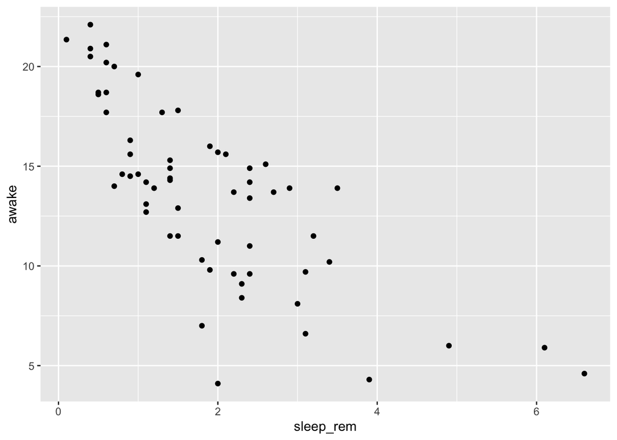

```r
# Example of a plot using theme_gray (the default)
ggplot(msleep) +
  aes(x = sleep_rem, y = awake) +
  geom_point() +
  # Optional, since this is the default
  theme_gray()
```

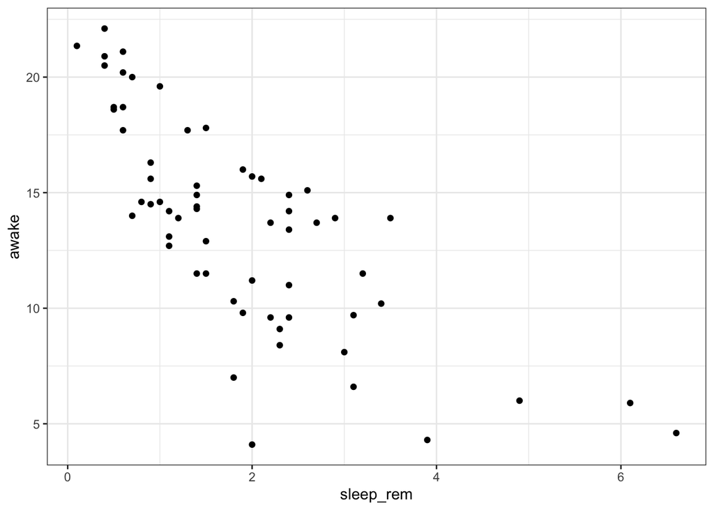

```r
# Example of a plot using theme_bw()
ggplot(msleep) +
  aes(x = sleep_rem, y = awake) +
  geom_point() +
  theme_bw()
```

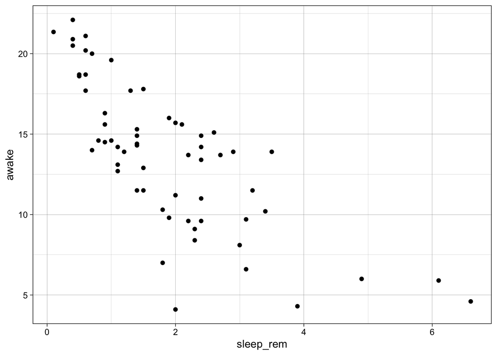

```r
# Example of a plot using theme_linedraw()
ggplot(msleep) +
  aes(x = sleep_rem, y = awake) +
  geom_point() +
  theme_linedraw()
```

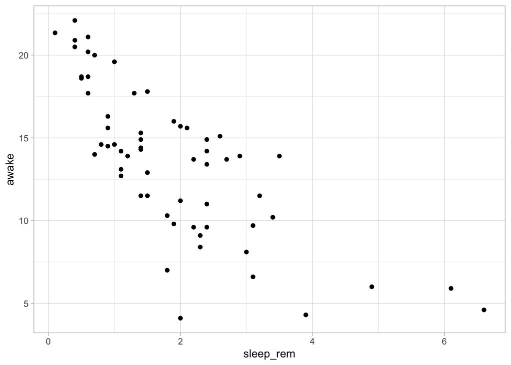

```r
# Example of a plot using theme_light()
ggplot(msleep) +
  aes(x = sleep_rem, y = awake) +
  geom_point() +
  theme_light()
```

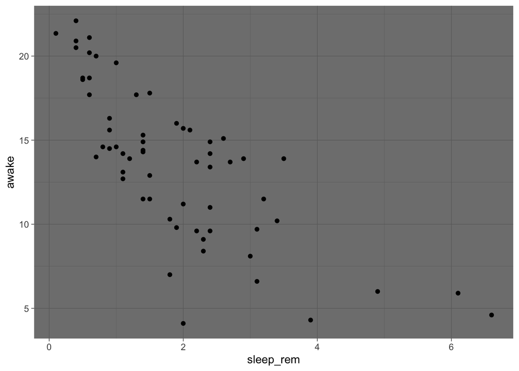

```r
# Example of a plot using theme_dark()
ggplot(msleep) +
  aes(x = sleep_rem, y = awake) +
  geom_point() +
  theme_dark()
```

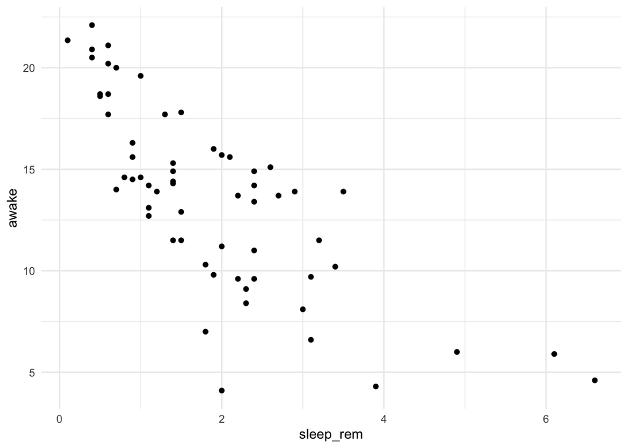

```r
# Example of a plot using theme_minimal()
ggplot(msleep) +
  aes(x = sleep_rem, y = awake) +
  geom_point() +
  theme_minimal()
```

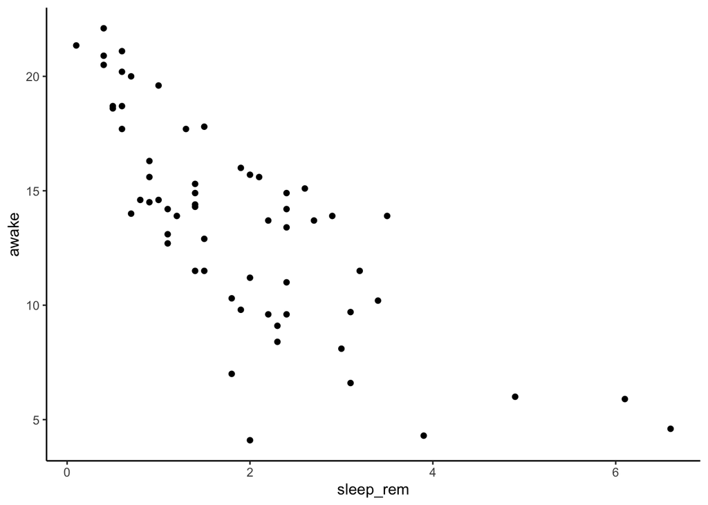

```r
# Example of a plot using theme_classic()
ggplot(msleep) +
  aes(x = sleep_rem, y = awake) +
  geom_point() +
  theme_classic()
```

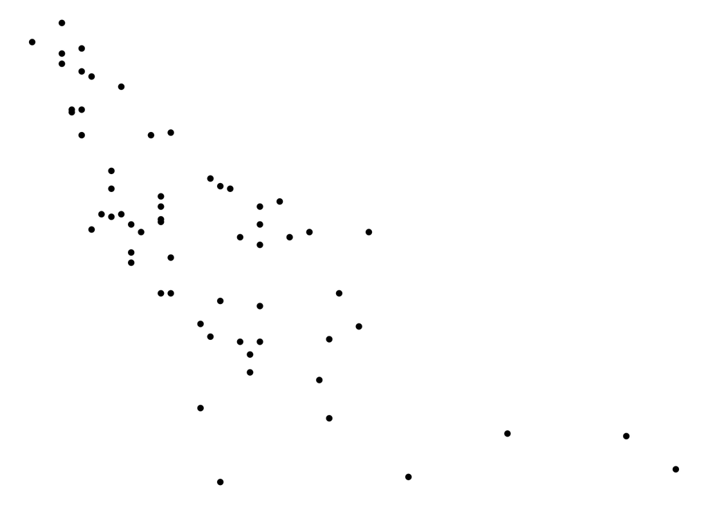

```r
# Example of a plot using theme_void()
# This theme is completely blank!
ggplot(msleep) +
  aes(x = sleep_rem, y = awake) +
  geom_point() +
  theme_void()
```